# The sensory panel as a measuring instrument

Block 4 · exercises 15 – 16

Sensometrics in R · SaIT

## The panel must be calibrated

In descriptive profiling the panel replaces a laboratory instrument. It must meet three conditions at once:

| pillar | question | ANOVA effect |
| --- | --- | --- |
| **discrimination** | does it separate products? | Product – we want a small p |
| **agreement** | does he/she rate like the others? | Product:Panelist – we want a large p |
| **repeatability** | the same when repeated? | Session, residual – small variance |

Dataset `sensochoc`: 29 assessors, 6 chocolates, 2 sessions, 14 descriptors.

## Performance of the whole panel

```r
perf <- panelperf(sensochoc, firstvar = 5,
  formul = "~Product+Panelist+Session+Product:Panelist+Product:Session+Panelist:Session")
round(perf$p.value[c("CocoaA", "Bitterness", "Caramel", "Granular"), 1:4], 3)
```

```
           Product          Panelist         Session          Product:Panelist
CocoaA                    0                0            0.239            0.993
Bitterness                0                0            0.012            0.026
Caramel                   0                0            0.949            0.003
Granular                  0                0            0.147            0.015
```

CocoaA: an ideal descriptor. Caramel, Granular: assessors disagree on the product order. Bitterness: a shift between sessions.

## Which descriptors does the panel discriminate best?

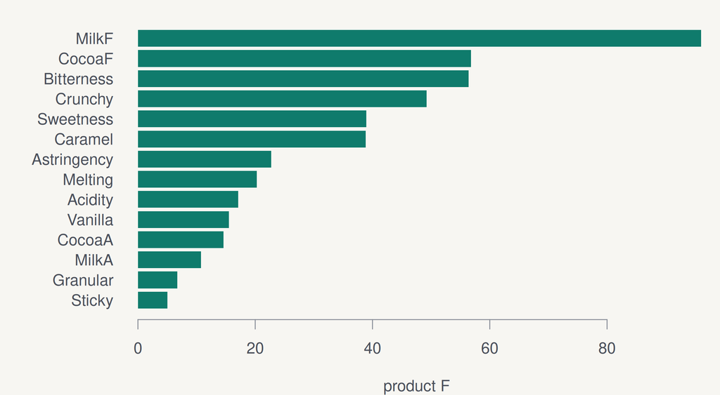

```r
F_prod <- sapply(names(sensochoc)[5:18], function(v) {
  a <- summary(aov(reformulate(
    c("Product", "Panelist", "Session"), v),
    data = sensochoc))[[1]]
  a[1, "F value"]
})
par(mar = c(4, 7, 1, 1))
barplot(sort(F_prod), horiz = TRUE, las = 1,
        col = pal[1], border = NA,
        xlab = "product F")
```

The higher F, the better the panel separates the products. `coltable()` from SensoMineR shows the same as a coloured table of p-values.

## Agreement and repeatability of assessors

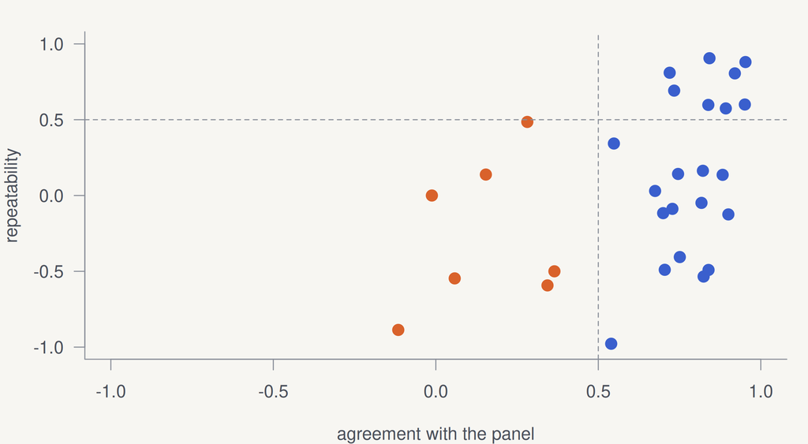

```r
avg <- with(sensochoc, tapply(CocoaA, list(Product, Panelist), mean))
agreement <- apply(avg, 2, cor, y = rowMeans(avg))
s1 <- with(subset(sensochoc, Session == 1),
           tapply(CocoaA, list(Product, Panelist), mean))
s2 <- with(subset(sensochoc, Session == 2),
           tapply(CocoaA, list(Product, Panelist), mean))
rep_ <- sapply(colnames(s1), function(h) cor(s1[, h], s2[, h]))
weak <- agreement < 0.5 & rep_ < 0.5
plot(agreement, rep_, pch = 19, cex = 1.4,
     col = ifelse(weak, pal[2], pal[3]),
     xlim = c(-1, 1), ylim = c(-1, 1),
     xlab = "agreement with the panel", ylab = "repeatability")
abline(h = 0.5, v = 0.5, lty = 2)
```

The orange assessors (7) are below the limit on both indicators – candidates for retraining.

## QUIZ What to do with the assessor?

An assessor has high **repeatability** but low **agreement** with the panel. What does it mean?

He/she rates consistently, but “in their own way” – probably understands the descriptor differently. Solution: **calibration with reference standards**, not removal.

## Fixed vs. random effects

|  | fixed | random |
| --- | --- | --- |
| levels | chosen deliberately | random sample from a population |
| example | **product** | **assessor**, batch, day |
| in `lmer` | `Product` | `(1 \| Panelist)` |

We want “A is better than B” for **any** similar panel, not just our 29 people → the product is tested against **assessor disagreement** (the interaction).

## Fixed model vs. mixed model

```r
tab <- summary(aov(Bitterness ~ Product * Panelist, data = sensochoc))[[1]]
rownames(tab) <- trimws(rownames(tab))
c(F_fixed = tab["Product", "F value"],
  F_vs_interaction = tab["Product", "Mean Sq"] / tab["Product:Panelist", "Mean Sq"])
```

```
         F_fixed F_vs_interaction
        59.87646         49.87641
```

```r
m <- lmer(Bitterness ~ Product + Session + (1 | Panelist) + (1 | Panelist:Product), data = sensochoc)
anova(m)
```

```
Type III Analysis of Variance Table with Satterthwaite's method
        Sum Sq Mean Sq NumDF DenDF F value    Pr(>F)
Product 783.92 156.784     5   140  49.876 < 2.2e-16 ***
Session  31.68  31.681     1   173  10.078  0.001776 **
---
Signif. codes:  0 '***' 0.001 '**' 0.01 '*' 0.05 '.' 0.1 ' ' 1
```

## Variance decomposition

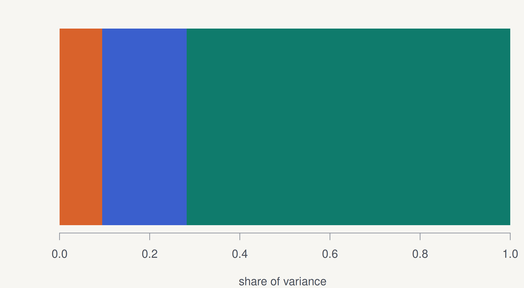

```r
vc <- as.data.frame(VarCorr(m))
share <- setNames(vc$vcov / sum(vc$vcov),
                  c("interaction", "assessor", "residual"))
barplot(as.matrix(share), horiz = TRUE,
        col = pal[c(2, 3, 1)], border = NA,
        xlab = "share of variance")
```

```r
round(share, 2)
```

```
interaction    assessor    residual
       0.09        0.19        0.72
```

A large **interaction** = poor agreement. A large **residual** = poor repeatability. The bridge between panel performance and the model.

## Post-hoc in a mixed model

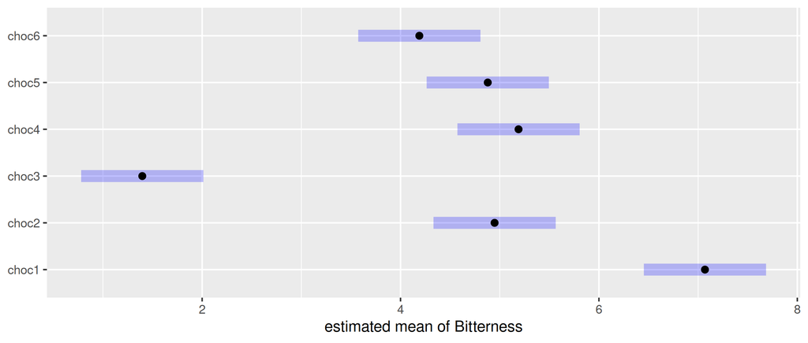

```r
comp <- emmeans(m, pairwise ~ Product, adjust = "tukey")
plot(comp$emmeans) + ggplot2::labs(x = "estimated mean of Bitterness", y = NULL)
```

## QUIZ Singular fit

For CocoaA, `lmer` prints the warning **“boundary (singular) fit”**. What happened?

The variance of the assessor × product interaction is estimated as **0** (interaction p = 0.99) – assessors agree on CocoaA. The model is usable; the effect can be dropped.

## Summary

- Check the panel regularly: **discrimination, agreement, repeatability**.
- Weak assessor → **calibration** first, removal only at the end.
- The assessor is a **random effect** → `lmer(y ~ Product + (1 | Panelist) + (1 | Panelist:Product))`.
- Post-hoc with `emmeans`, not `TukeyHSD`.

Theory 15 Theory 16